# 時系列分析 第 6 回 データの読込・編集

Kenichiro Tamaki

2022 年 5 月 16 日

# 1 データの読込

例として, NHK が提供している新型コロナウイルスの都道府県別データを用いる.

- https://www3.nhk.or.jp/news/special/coronavirus/data/

上記から, CSV ファイル「nhk_news_covid19_prefectures_daily_data.csv」をダウンロードする.

RStudio の右上にある「Environment」→「Import Dateset」→「From Text (readr)…」において, CSV ファイルの読込が出来る (次が実行される).

```r
library(readr) # パッケージを読み込む
# CSV ファイルを読み込み, 変数に代入 (変数名はファイル名と同じ)
nhk_news_covid19_prefectures_daily_data <- read_csv("nhk_news_covid19_prefectures_daily_data.csv")
View(nhk_news_covid19_prefectures_daily_data) # データを見る
```

# 2 データの確認

## 2.1 データの確認

まず, 変数名が長いので変更する.

```r
covid19 <- nhk_news_covid19_prefectures_daily_data # 変数名を変更
```

次に, データの中身を確認する.

```r
head(covid19, 5) # 最初の 5 個を表示
```

```
## # A tibble: 5 x 8
##   日付      都道府県コード 都道府県名 各地の感染者数_1日ごとの~ 各地の感染者数_~
##   <chr>     <chr>          <chr>                          <dbl>            <dbl>
## 1 2020/1/16 01             北海道                             0                0
## 2 2020/1/17 01             北海道                             0                0
## 3 2020/1/18 01             北海道                             0                0
## 4 2020/1/19 01             北海道                             0                0
## 5 2020/1/20 01             北海道                             0                0
## # ... with 3 more variables: 各地の死者数_1日ごとの発表数 <dbl>,
## #   各地の死者数_累計 <dbl>, 各地の直近1週間の人口10万人あたりの感染者数 <dbl>
```

```r
tail(covid19, 5) # 最後の 5 個を表示
```

```
## # A tibble: 5 x 8
##   日付      都道府県コード 都道府県名 各地の感染者数_1日ごとの~ 各地の感染者数_~
##   <chr>     <chr>          <chr>                          <dbl>            <dbl>
## 1 2022/5/10 47             沖縄県                          2265           176720
## 2 2022/5/11 47             沖縄県                          2702           179422
## 3 2022/5/12 47             沖縄県                          2330           181752
## 4 2022/5/13 47             沖縄県                          2242           183994
## 5 2022/5/14 47             沖縄県                          2464           186458
## # ... with 3 more variables: 各地の死者数_1日ごとの発表数 <dbl>,
## #   各地の死者数_累計 <dbl>, 各地の直近1週間の人口10万人あたりの感染者数 <dbl>
```

列名も長いので変更する.

```r
item <- c("感染者数日毎", "感染者数累計", "死者数日毎", "死者数累計", "感染者数/10万人") # 列名を作成
n.item <- length(item) # 項目数
colnames(covid19)[4:(n.item + 3)] <- item # 列名を変更
```

## 2.2 欠損値の確認

欠損値の有無を確認する.

```r
sum(is.na(covid19)) # 欠損値の数
```

```
## [1] 282
```

欠損値が存在するので削除する.

```r
covid19 <- na.omit(covid19) # 欠損値を削除
sum(is.na(covid19)) # 欠損値の数
```

```
## [1] 0
```

欠損値の数が 0 であるので, 欠損値はない.

## 2.3 整合性の確認

都道府県別の日付情報が同じであるか確認する. 準備として都道府県コードと都道府県名を取り出す.

```r
pcode <- unique(covid19$都道府県コード) # 都道府県コードを取り出す
pcode # 都道府県コードを表示
```

```
##  [1] "01" "02" "03" "04" "05" "06" "07" "08" "09" "10" "11" "12" "13" "14" "15"
## [16] "16" "17" "18" "19" "20" "21" "22" "23" "24" "25" "26" "27" "28" "29" "30"
## [31] "31" "32" "33" "34" "35" "36" "37" "38" "39" "40" "41" "42" "43" "44" "45"
## [46] "46" "47"
```

```r
pref <- unique(covid19$都道府県名) # 都道府県名を取り出す
pref # 都道府県名を表示
```

```
##  [1] "北海道"   "青森県"   "岩手県"   "宮城県"   "秋田県"   "山形県"
##  [7] "福島県"   "茨城県"   "栃木県"   "群馬県"   "埼玉県"   "千葉県"
## [13] "東京都"   "神奈川県" "新潟県"   "富山県"   "石川県"   "福井県"
## [19] "山梨県"   "長野県"   "岐阜県"   "静岡県"   "愛知県"   "三重県"
## [25] "滋賀県"   "京都府"   "大阪府"   "兵庫県"   "奈良県"   "和歌山県"
## [31] "鳥取県"   "島根県"   "岡山県"   "広島県"   "山口県"   "徳島県"
## [37] "香川県"   "愛媛県"   "高知県"   "福岡県"   "佐賀県"   "長崎県"
## [43] "熊本県"   "大分県"   "宮崎県"   "鹿児島県" "沖縄県"
```

```r
n.pref <- length(pref) # 都道府県数
n.pref # 都道府県数を表示
```

```
## [1] 47
```

都道府県コード 01 (北海道) の日付情報を基準として調べる.

```r
c01 <- covid19[covid19$都道府県コード == "01",] # 都道府県コード 01 (北海道) のデータ
date01 <- c01$日付 # 北海道の日付情報
head(date01, 5) # 日付情報の最初の 5 個を表示
```

```
## [1] "2020/1/22" "2020/1/23" "2020/1/24" "2020/1/25" "2020/1/26"
```

他の都道府県の日付情報が北海道と同じであるか確認する.

```r
date.check <- numeric(n.pref) # 確認用の変数を作成
for (i in 2:n.pref) {
    x <- covid19[covid19$都道府県コード == pcode[i],] # 都道府県コードが i 番目のデータ
    date.check[i] <- sum(date01 != x$日付) # 北海道の日付情報と異なる数
}
date.check # 都道府県別の北海道の日付情報と異なる数
```

```
##  [1] 0 0 0 0 0 0 0 0 0 0 0 0 0 0 0 0 0 0 0 0 0 0 0 0 0 0 0 0 0 0 0 0 0 0 0 0 0 0
## [39] 0 0 0 0 0 0 0 0 0
```

全て 0 であるので, 都道府県の日付情報は全て同じである.

# 3 データの編集

次の方法を紹介する.

- 時系列データへ変換
- 都道府県別の変数を作成
- 項目毎の変数を作成

## 3.1 時系列データへ変換

時系列データへ変換し全部を格納した変数 (c.all) を作成する.

```r
library(quantmod) # パッケージを読み込む
c.all <- NULL # 全部を格納する変数を作成
for (i in 1:n.pref) {
    x <- covid19[covid19$都道府県コード == pcode[i],] # 都道府県コードが i 番目のデータ
    x <- x[,-c(2, 3)] # 都道府県コードと都道府県名を削除
    x <- as.xts(read.zoo(x)) # 時系列データへ変換
    c.all <- cbind(c.all, x) # データを結合
}
```

## 3.2 都道府県別の変数

全て格納した時系列データの変数 (c.all) を用いて, 都道府県別に変数 (c + 都道府県コード) を作成する. つまり, 北海道は変数 (c01), 青森県は変数 (c02), …, 東京都は変数 (c13), …, 沖縄県は変数 (c47) を作成し格納する.

```r
colnames(c.all) <- rep(item, 47) # 列名を変更
for (i in 1:n.pref) {
    vname <- paste("c", pcode[i], sep = "") # 変数名を作成
    assign(vname, c.all[,(n.item * (i - 1) + 1):(n.item * i)]) # 変数に格納
}
```

```r
pcode[which(pref == "東京都")] # 東京都のコード
```

```
## [1] "13"
```

```r
head(c13, 5) # 東京都の最初の 5 個を表示
```

```
##            感染者数日毎 感染者数累計 死者数日毎 死者数累計 感染者数/10万人
## 2020-01-22            0            0          0          0            0.00
## 2020-01-23            0            0          0          0            0.00
## 2020-01-24            1            1          0          0            0.01
## 2020-01-25            1            2          0          0            0.01
## 2020-01-26            0            2          0          0            0.01
```

```r
tail(c13, 5) # 東京都の最後の 5 個を表示
```

```
##            感染者数日毎 感染者数累計 死者数日毎 死者数累計 感染者数/10万人
## 2022-05-10         4451      1471547          2       4370          170.72
## 2022-05-11         4764      1476311          5       4375          183.28
## 2022-05-12         4216      1480527          4       4379          196.78
## 2022-05-13         4109      1484636          4       4383          206.95
## 2022-05-14         3799      1488435         10       4393          206.88
```

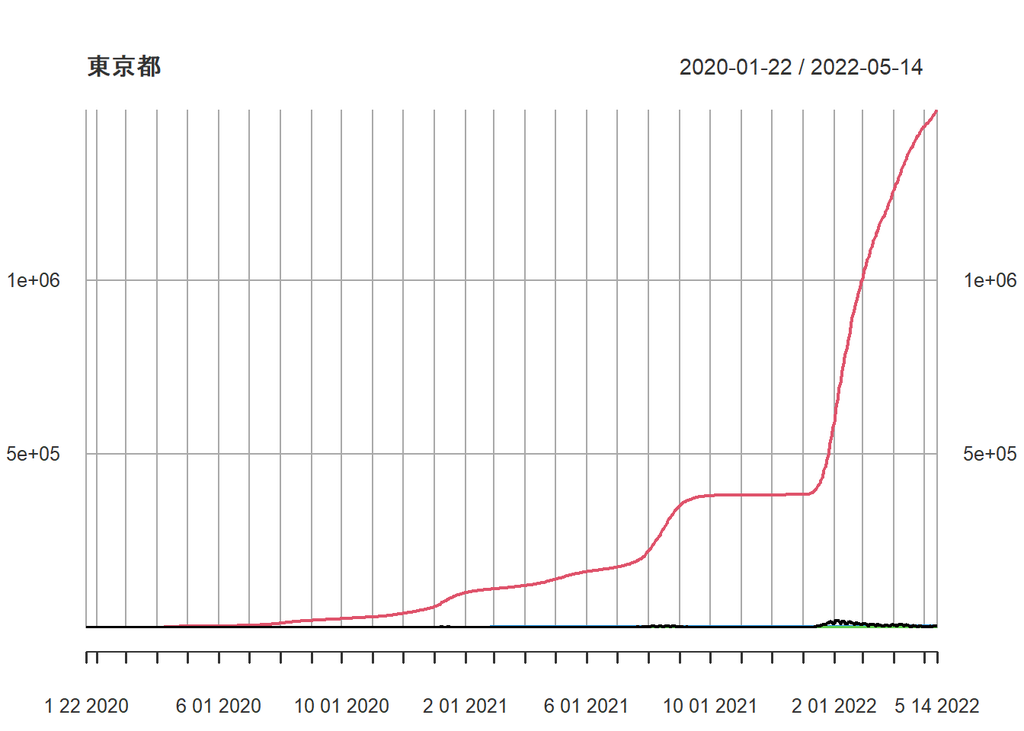

```r
plot(c13, main = pref[13])
```

```r
pcode[which(pref == "大阪府")] # 大阪府のコード
```

```
## [1] "27"
```

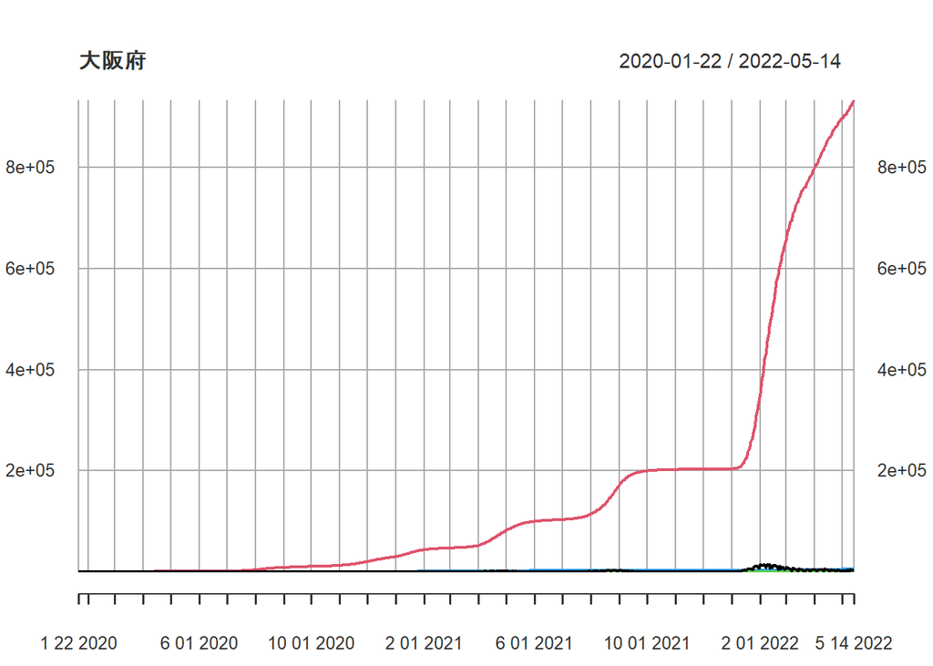

```r
plot(c27, main = pref[27])
```

## 3.3 項目毎の変数

全て格納した時系列データの変数 (c.all) を用いて, 項目毎に変数を作成する. つまり, 感染者数日毎は変数 (c.all1), 感染者数累計は変数 (c.all2), 死者数日毎は変数 (c.all3), 死者数累計は変数 (c.all4), 感染者数/10万人は変数 (c.all5) を作成し格納する.

```r
colnames(c.all) <- rep(pref, rep(5, 47)) # 列名を変更
for (i in 1:n.item) {
    vname <- paste("c.all", i, sep = "") # 変数名を作成
    assign(vname, c.all[,seq(i, 47 * n.item, n.item)]) # 変数に格納
}
```

```r
head(c.all1) # 感染者数日毎の最初の 5 個を表示
```

```
##            北海道 青森県 岩手県 宮城県 秋田県 山形県 福島県 茨城県 栃木県
## 2020-01-22      0      0      0      0      0      0      0      0      0
## 2020-01-23      0      0      0      0      0      0      0      0      0
## 2020-01-24      0      0      0      0      0      0      0      0      0
## 2020-01-25      0      0      0      0      0      0      0      0      0
## 2020-01-26      0      0      0      0      0      0      0      0      0
## 2020-01-27      0      0      0      0      0      0      0      0      0
##            群馬県 埼玉県 千葉県 東京都 神奈川県 新潟県 富山県 石川県 福井県
## 2020-01-22      0      0      0      0        0      0      0      0      0
## 2020-01-23      0      0      0      0        0      0      0      0      0
## 2020-01-24      0      0      0      1        0      0      0      0      0
## 2020-01-25      0      0      0      1        0      0      0      0      0
## 2020-01-26      0      0      0      0        0      0      0      0      0
## 2020-01-27      0      0      0      0        0      0      0      0      0
##            山梨県 長野県 岐阜県 静岡県 愛知県 三重県 滋賀県 京都府 大阪府
## 2020-01-22      0      0      0      0      0      0      0      0      0
## 2020-01-23      0      0      0      0      0      0      0      0      0
## 2020-01-24      0      0      0      0      0      0      0      0      0
## 2020-01-25      0      0      0      0      0      0      0      0      0
## 2020-01-26      0      0      0      0      1      0      0      0      0
## 2020-01-27      0      0      0      0      0      0      0      0      0
##            兵庫県 奈良県 和歌山県 鳥取県 島根県 岡山県 広島県 山口県 徳島県
## 2020-01-22      0      0        0      0      0      0      0      0      0
## 2020-01-23      0      0        0      0      0      0      0      0      0
## 2020-01-24      0      0        0      0      0      0      0      0      0
## 2020-01-25      0      0        0      0      0      0      0      0      0
## 2020-01-26      0      0        0      0      0      0      0      0      0
## 2020-01-27      0      0        0      0      0      0      0      0      0
##            香川県 愛媛県 高知県 福岡県 佐賀県 長崎県 熊本県 大分県 宮崎県
## 2020-01-22      0      0      0      0      0      0      0      0      0
## 2020-01-23      0      0      0      0      0      0      0      0      0
## 2020-01-24      0      0      0      0      0      0      0      0      0
## 2020-01-25      0      0      0      0      0      0      0      0      0
## 2020-01-26      0      0      0      0      0      0      0      0      0
## 2020-01-27      0      0      0      0      0      0      0      0      0
##            鹿児島県 沖縄県
## 2020-01-22        0      0
## 2020-01-23        0      0
## 2020-01-24        0      0
## 2020-01-25        0      0
## 2020-01-26        0      0
## 2020-01-27        0      0
```

```r
tail(c.all1) # 感染者数日毎の最後の 5 個を表示
```

```
##            北海道 青森県 岩手県 宮城県 秋田県 山形県 福島県 茨城県 栃木県
## 2022-05-09   2556    363    232    239    189    122    451    794    289
## 2022-05-10   2400    379    307    640    372    168    505    573    475
## 2022-05-11   3259    415    314    623    262    261    595    595    550
## 2022-05-12   3176    444    276    475    223    205    560    649    408
## 2022-05-13   3034    373    292    494    233    255    498    645    391
## 2022-05-14   2771    353    261    512    202    284    529    641    397
##            群馬県 埼玉県 千葉県 東京都 神奈川県 新潟県 富山県 石川県 福井県
## 2022-05-09    236   1638    982   3011     1662    427    111    521    296
## 2022-05-10    509   1473   1153   4451     2202    401    178    235    346
## 2022-05-11    446   1910   1372   4764     2340    553    310    625    339
## 2022-05-12    361   1774   1233   4216     1841    464    240    576    336
## 2022-05-13    360   1566   1109   4109     2012    423    235    527    357
## 2022-05-14    395   1439   1059   3799     2077    460    276    499    356
##            山梨県 長野県 岐阜県 静岡県 愛知県 三重県 滋賀県 京都府 大阪府
## 2022-05-09    112    246    410    568   1209    371    293    546   1486
## 2022-05-10    152    458    824   1027   3000    382    452    835   4240
## 2022-05-11    158    445    612   1167   2729    556    355   1061   3679
## 2022-05-12    133    446    629   1242   2373    459    522    936   3290
## 2022-05-13    146    413    610   1084   2453    432    410    907   3210
## 2022-05-14    132    421    538   1094   2472    372    347    884   3439
##            兵庫県 奈良県 和歌山県 鳥取県 島根県 岡山県 広島県 山口県 徳島県
## 2022-05-09    741    300      239    104    119    526   1112    173    110
## 2022-05-10   1822    168      238    128    160    668   1021    360    156
## 2022-05-11   1901    385      328    116    159   1035   1450    331    163
## 2022-05-12   1588    467      244    101    153    834   1503    291    139
## 2022-05-13   1569    299      311    118    150    722   1299    408    126
## 2022-05-14   1769    295      271    111    143    761   1247    319    136
##            香川県 愛媛県 高知県 福岡県 佐賀県 長崎県 熊本県 大分県 宮崎県
## 2022-05-09    272    160    134   1919    336    333    386    257    285
## 2022-05-10    437    321    366   2250    357    505    795    506    415
## 2022-05-11    481    237    249   2401    369    568    731    435    790
## 2022-05-12    365    241    281   2424    363    480    648    408    536
## 2022-05-13    320    212    265   2198    309    394    582    352    492
## 2022-05-14    362    212    257   2114    308    415    596    358    550
##            鹿児島県 沖縄県
## 2022-05-09      424   1071
## 2022-05-10      961   2265
## 2022-05-11      730   2702
## 2022-05-12      767   2330
## 2022-05-13      633   2242
## 2022-05-14      640   2464
```

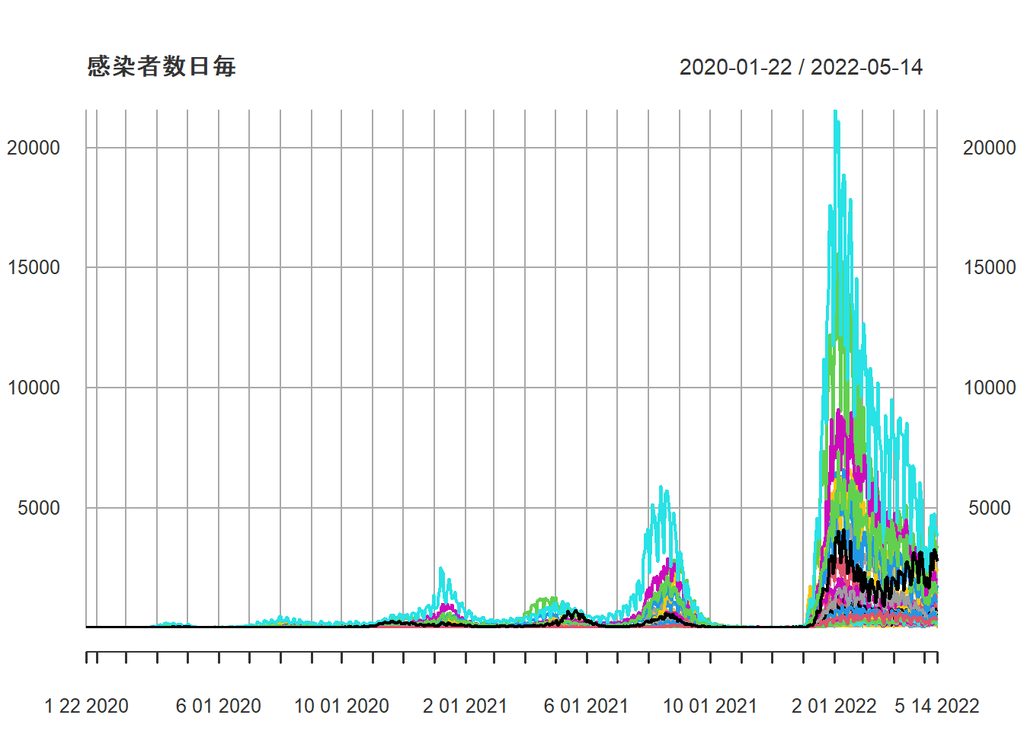

```r
plot(c.all1, main = item[1]) # 感染者数日毎
```

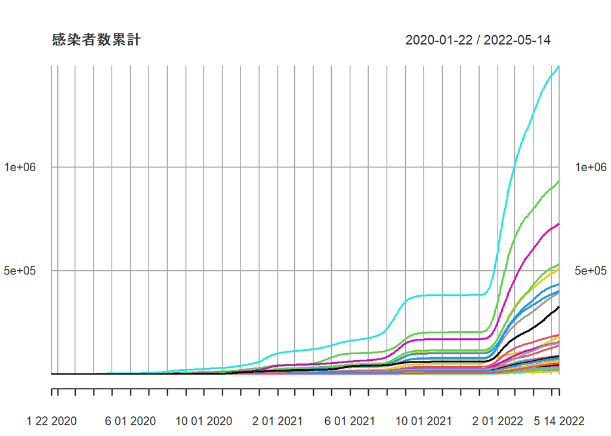

```r
plot(c.all2, main = item[2]) # 感染者数累計
```

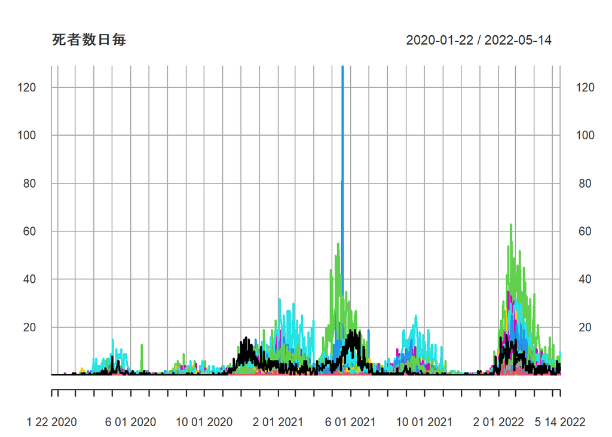

```r
plot(c.all3, main = item[3]) # 死者数日毎
```

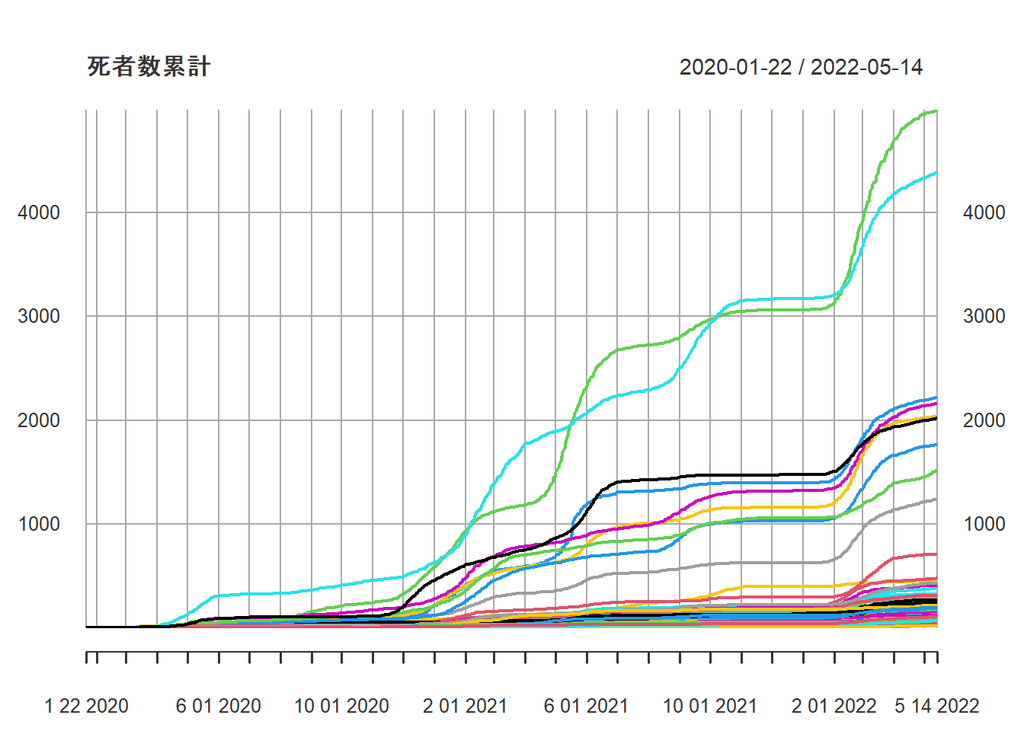

```r
plot(c.all4, main = item[4]) # 死者数累計
```

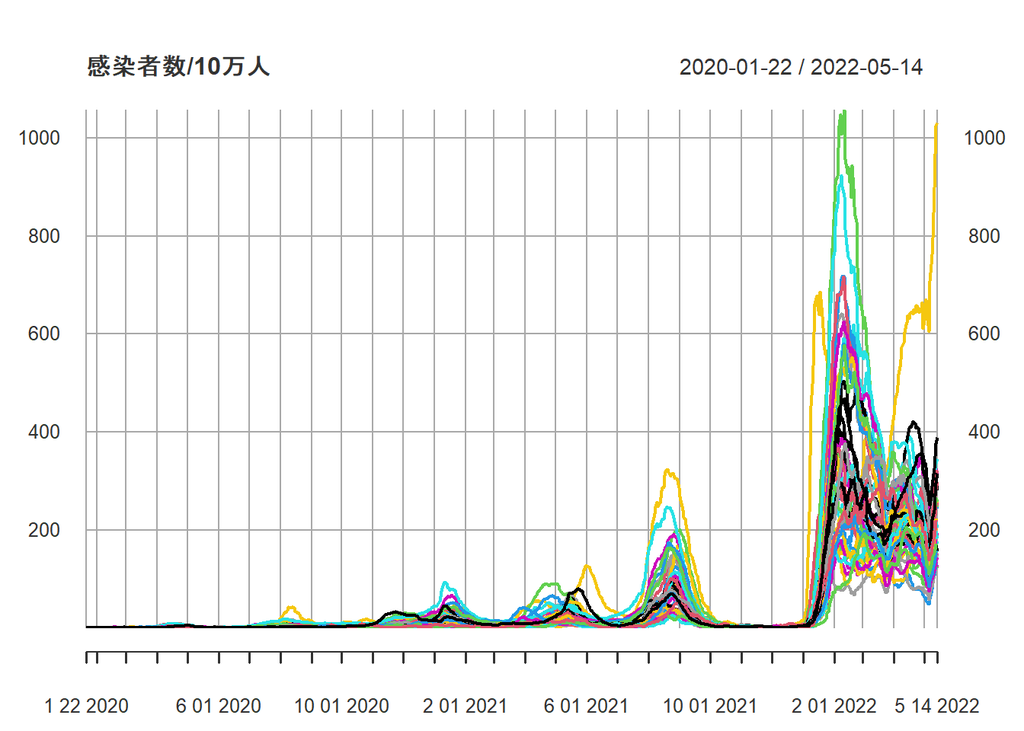

```r
plot(c.all5, main = item[5]) # 感染者数/10万人
```